# Using Time Series to Indirectly Predict Weather Patterns

Kaylyn Vo

Fall, 2019

# 1. Summary

The data consist of measurements of silt and sediment deposits at a particular location over a period of 624 years. By predicting the values of the sediment deposits, we are indirectly predicting temperatures and weather patterns. After careful inspection of the data and using time series analysis, we determined that the data was generated from a model that composed of three components meaning that the current measurement of sediment deposits depends on the weighted average of the previous year’s sediment deposit and the variation of previous year’s temperature and sediment deposits and other unknown factors. We also used the model to predict ten measurements and the results are within the range of past values. Additionally, as in seen the plot of the original data, there are quite variability in the observations in the last two hundred and fifty years. In order to understand more about how silt deposits can be modeled as an ARMA(1,1), we can collaborate with climate scientist in further studies.

# 2. Importing Library

```r
library(tseries)
```

# 3. About the Data

During a warming period on Earth, glaciers melt and the melted ice, now water, carries silt and sand downstream from the mountainside beside the glacier and is deposited in a layer usually at the floor of a valley below the glacier. The warmer the season, the more ice melts and the more sand and silt is carried downstream. In the winter, this layer of sediment hardens, and is thus differentiable from the layer from the previous year and the subsequent year. Thus, looking at these layers of silt and sediment can give an indication of the temperature changes from one year to the next. Our data is the thickness of the sedimentary deposits each year over a period of 624 years at one particular location. Of course there is random variation; two years with the same temperature will not necessarily leave exactly the same amount of sediment at the valley floor. Not only that, the amount of variability in the thickness of the sedimentary layer is related to the temperature, e.g., in a relatively cold year there will not be much melt and thus not much sediment, so the variability in the thickness of the sedimentary layer will be small. In a warm year there will be a higher level of melt, and there is more variation in the thickness of the sedimentary deposits. Note that as we make predictions for future values of the thickness of the sedimentary value, we are in some sense making predictions of future weather patterns.

# 4. Exploratory Data Analysis

We began by looking at the plot of the raw data to determine whether it has met assumptions of first and second order stationary as seen in Figure 1. There are at least three things that we observed in the original observations: 1) curvilinear pattern, 2) the variance of the data doesn’t look constant, 3) the variation of the observations in the recent years is larger than when they were first collected. We used natural logarithmic on the data to stabilize the variance and differentiated the data to fix the curvilinear pattern. After the logarithmic transformation, there seems to be a sinusoidal patterns with a period of approximately 400 years. It seems that deposit reach its peak or base in about 200 years. After transformation and first order differencing, the transformation data has an approximately constant mean and constant variance as seen in Figure 3. We also used the Augmented Dickey-Fuller to determine the whether the data is first order stationary. The p-value of the test statistics of less than 0.01, so the assumption of first order stationary is satisfied.

## 4.A. Quick Examining of the Data

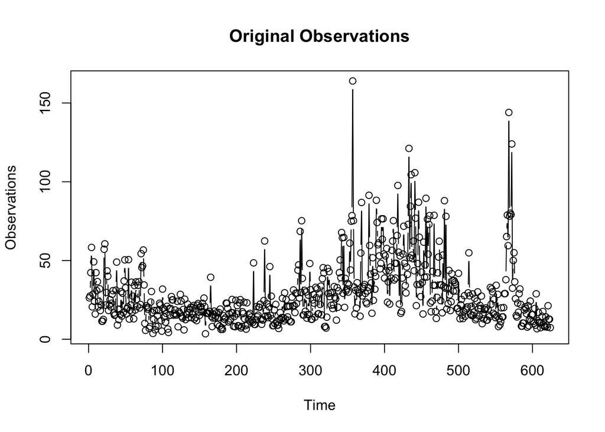

Figure 1: Scatter plot of the original data

Summary of the data

```
##    Min. 1st Qu.  Median    Mean 3rd Qu.    Max.
##    3.48   15.04   21.40   28.09   34.26  164.00
```

```r
adf.test(diff_log)
```

```
##
##  Augmented Dickey-Fuller Test
##
## data:  diff_log
## Dickey-Fuller = -11.703, Lag order = 8, p-value = 0.01
## alternative hypothesis: stationary
```

Table 1: Augmented Dickey-Fuller Test for Constant Mean

## 4.B. Time Series Plots

Now, we have data that approximately satisfies the first and second order statitonary. We plot the data of different time periods to determine if there are any patterns or periodicities. Figure 2 shows the first 90 observations and the last 90 observations, respectively. Both plots show spikes of irregular periods. Plots of 180 observations of different years period also show similar pattern of spikes as seen in Figure 3. If the data came from an AR, we would expect the the data to show periods of fixed length; however, the periods as seen in these plots are of irregular lengths.

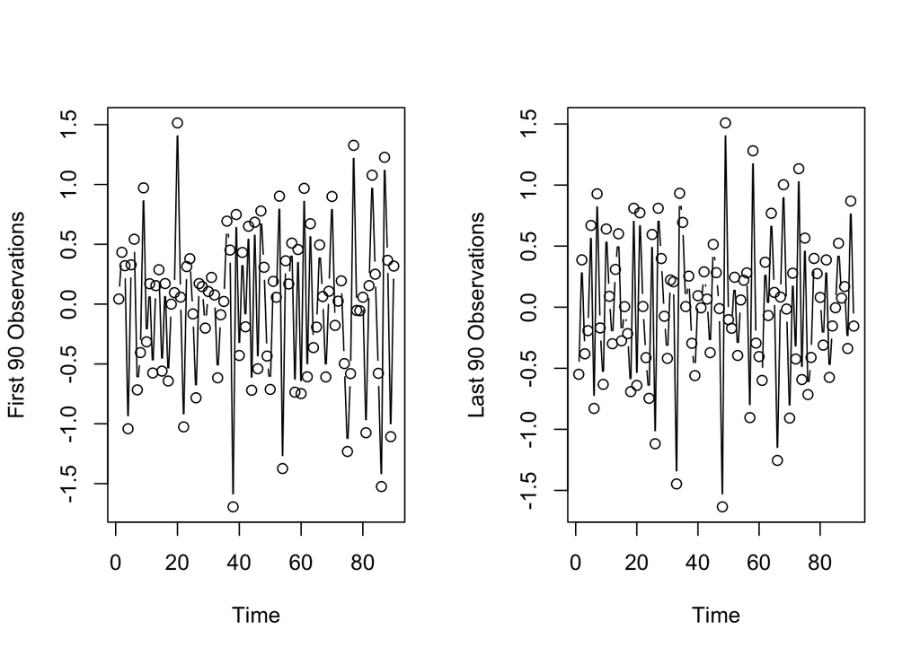

Figure 2. The first and last 90 of the transformed observations with differencing

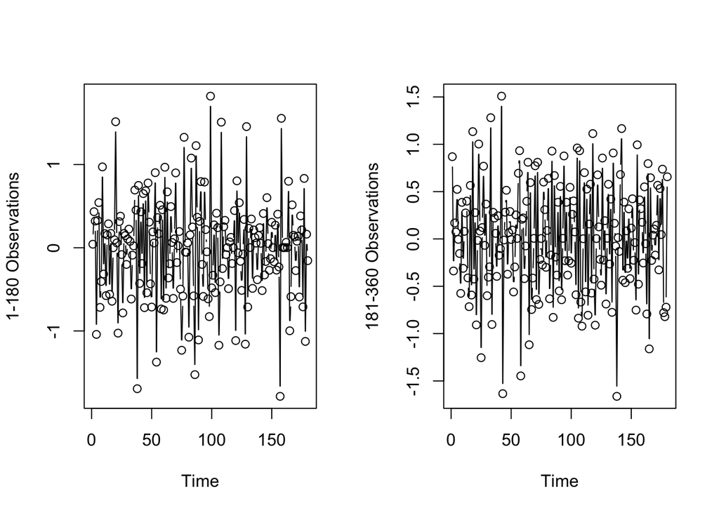

# 5. Sample ACF and PACF

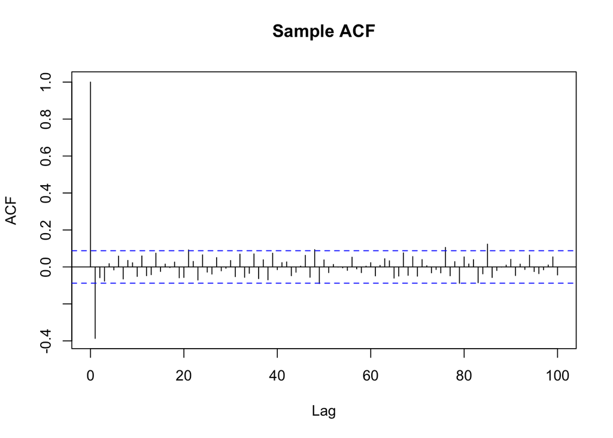

Figure 4. Sample Auto-Correlations

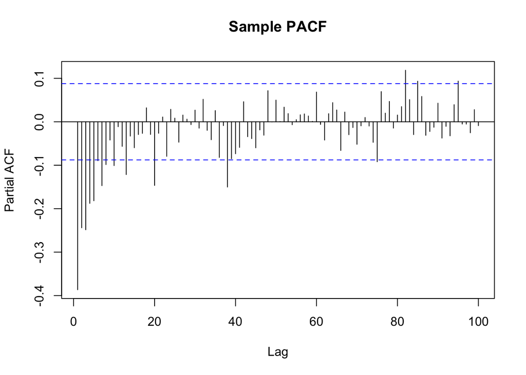

Figure 5. Sample Partial Auto-Correlations

# 6. Periodogram

We also used the sample periodogram to identify periods in the data. Specifically, we are looking for dips or peaks; however,there are not any obvious periods in sediment deposits. The periodogram as seen in Figure 6 has a slight dip at the frequency zero. This frequency associate with the positive root of the MA(p) components. As for AR components, There are not obvious peaks to suggest the data was from an AR(q) process. The periodogram is another tool that can assists us in analyzing the data, however it is not an absolute tool to determine the process. We used the sample periodogram in conjunction with the sample ACF and PACF to come up with several possible models. We will compare models using Mean Squared Error, AIC, and BIC.

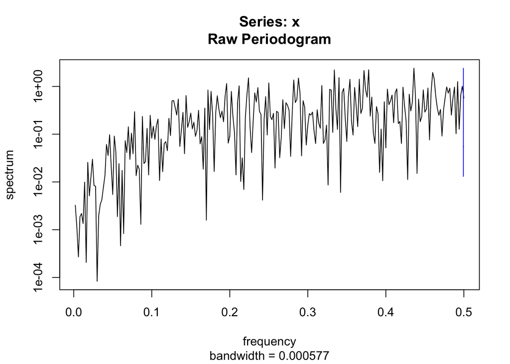

Figure 6. Sample Periodogram

# 7. Candidate Models

From the scatter plot, sample ACF, sample PACF, and sample periodogram, there are several possible models:

1. MA(1)
2. MA(2)
3. MA(3)
4. ARMA(1,1)
5. ARMA(2,1)
6. ARMA(3,1).

## 7.A. Fitting Models

```r
fit_ma_1 <- arima(log_deposit[1:499], order=c(0,1,1),xreg = 1:length(log_deposit[1:499]))
fit_ma_2 <- arima(log_deposit[1:499], order = c(0,1,2), xreg = 1:length(log_deposit[1:499]))
fit_ma_3 <- arima(log_deposit[1:499], order = c(0,1,3), xreg = 1:length(log_deposit[1:499]))
fit_arma_11 <- arima(log_deposit[1:499], order = c(1,1,1), xreg = 1:length(log_deposit[1:499]))
fit_arma_21 <- arima(log_deposit[1:499], order = c(2,1,1), xreg = 1:length(log_deposit[1:499]))
fit_arma_31 <- arima(log_deposit[1:499], order = c(3,1,1), xreg = 1:length(log_deposit[1:499]))
```

## 7.B. Models Diagnostics

We have fitted several candidate time series models, next we will look at the diagnostics plot of each individual model to examine whether the assumption of the residuals is satisfied. All candidate models’ residuals satisfied the normality assumption except for MA(1). The p-values for Ljung-Box statistics table in Figure 7 are all small which means that the underlying population correlations are correlated. If the errors are correlated then the assumption of Normality is not satisfied. Thus, we dropped MA(1) from our pool of candidate models. Other models’ diagnostics plots can be seen in Figure 8,9,10, and 11.

### 7.B.1 MA(1)

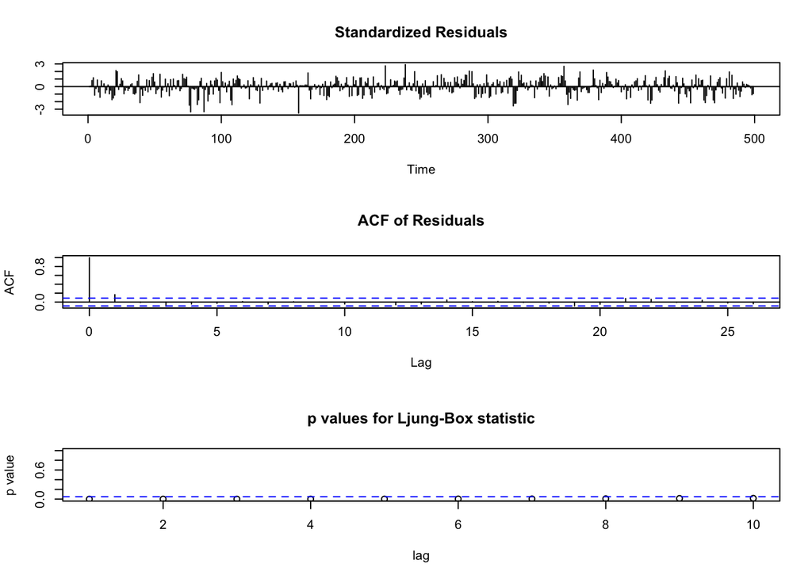

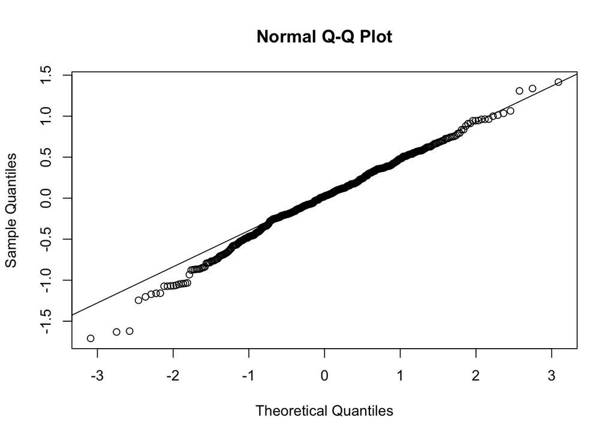

Figure 7. Diagnostics of residuals of MA(1)

### 7.B.2 MA(2)

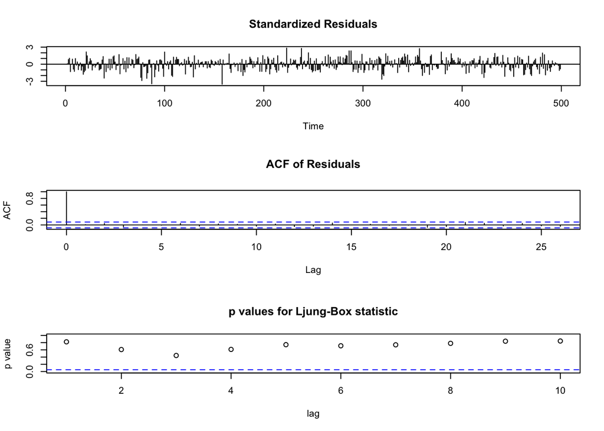

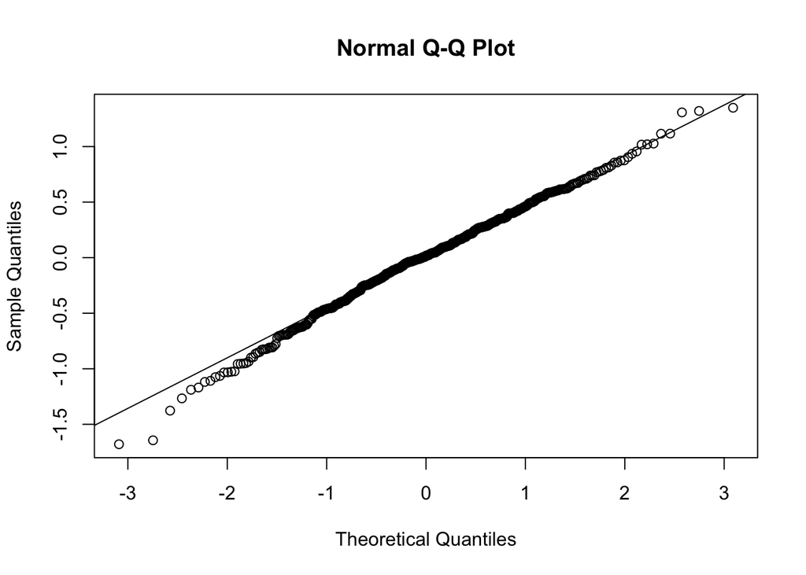

Figure 8. Diagnostics of residuals of MA(2)

### 7.B.3. MA(3)

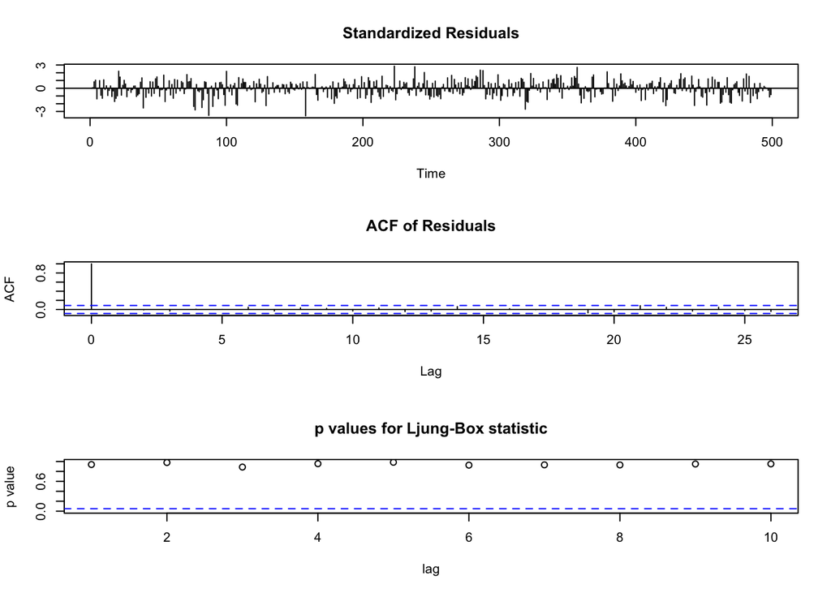

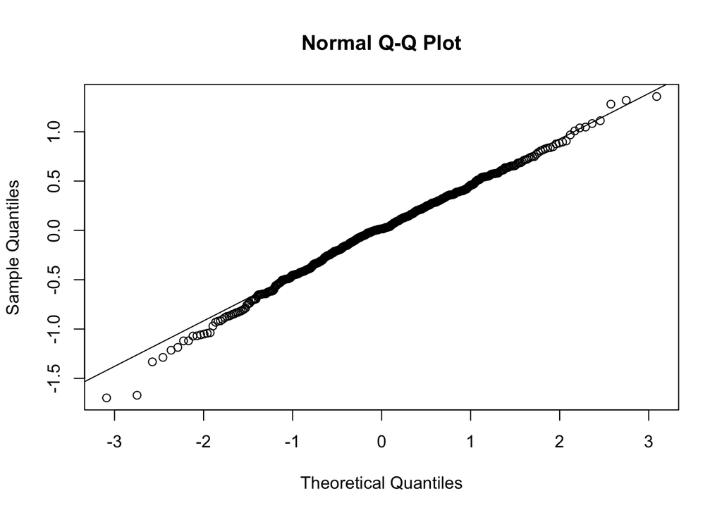

Figure 9. Diagnostics of residuals of MA(3)

### 7.B.4 ARMA(1,1)

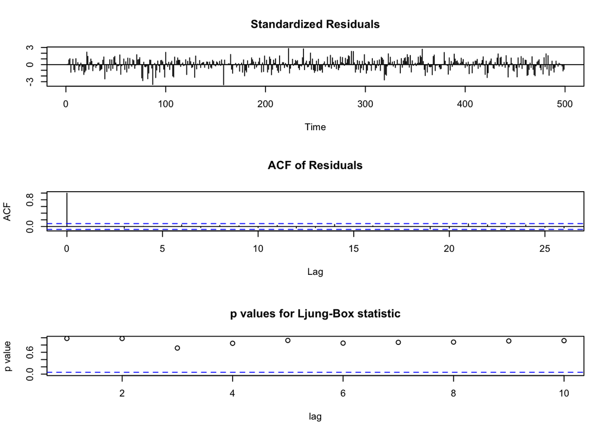

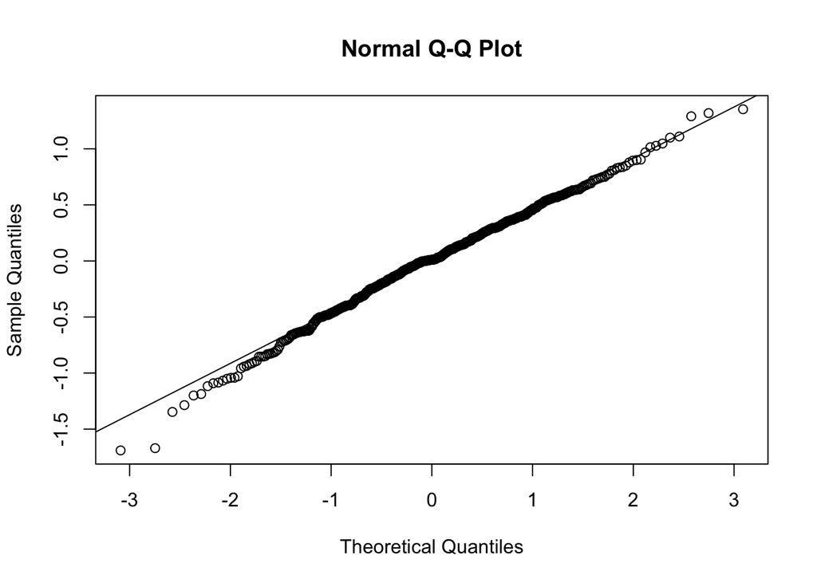

Figure 10. Diagnostics of residuals of ARMA(1,1)

### 7.B.5 ARMA(2,1)

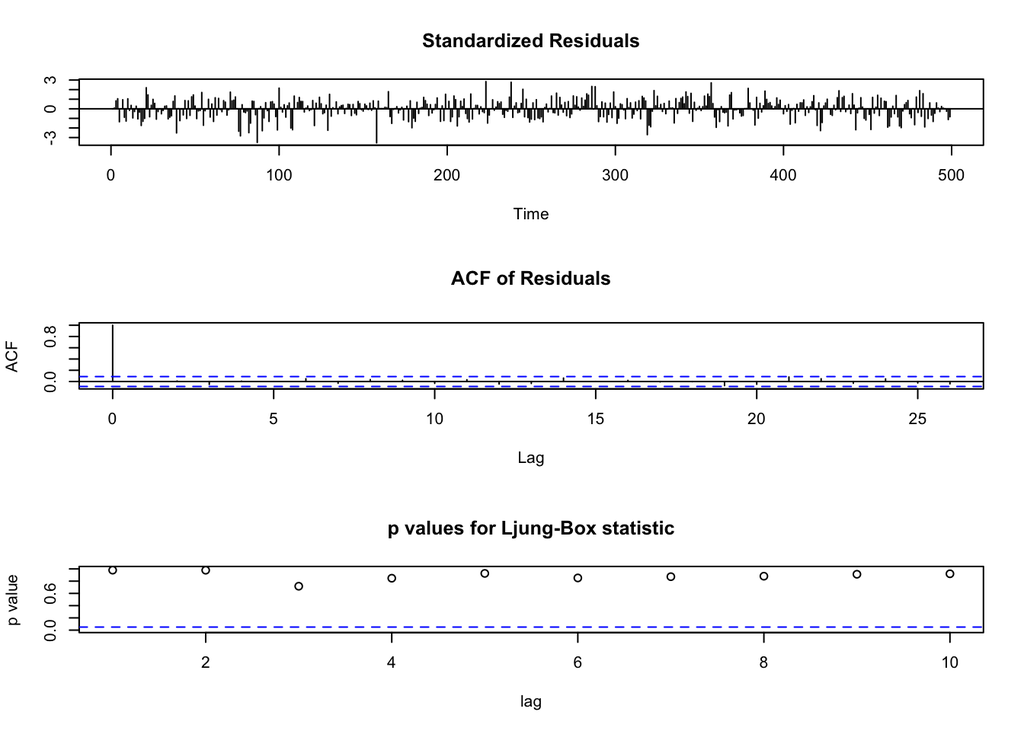

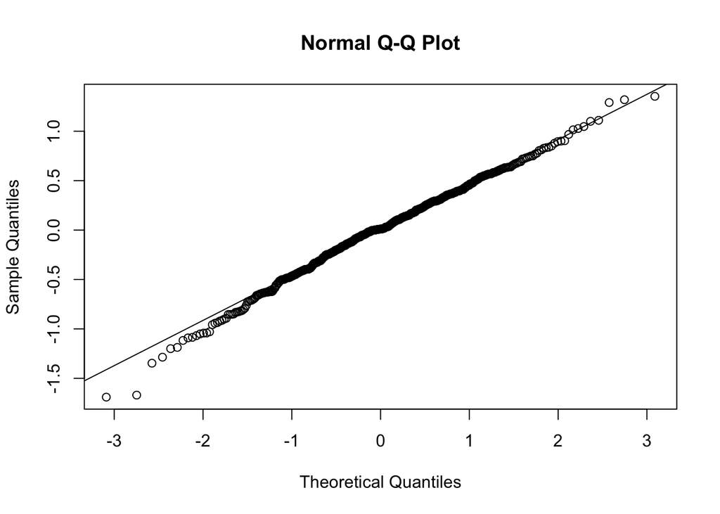

Figure 11. Diagnostics of residuals of ARMA(2,1)

## 7.C. AIC and BIC Scores

All possible models were fitted using R’s arima function. We looked at the diagnostic of each model. One of the assumptions is that the errors of the model is assumed to be identically and independently Normal distributed. Upon inspecting the residuals of the model MA(1), the white noise assumption is not satisfied because there are serial correlations of the residuals. We decided to drop it from one of the possible candidates. The distributions of residuals from the rest of the other models are approximately Normal distributed. We calculated Akaike Information Criteria (AIC) and Bayesian Information Criteria (BIC) of the remaining candidates MA(2), MA(3), ARMA(1,1),and ARMA(2,1)

The AIC and BIC are computed by using the following equations:

- AIC Score = $-2*-loglikelihood + 2*(p+q+1)$
- BIC Score = $-2*-loglikelihood + ln(n)*(p+q+1)$

where n is the total number of observations and p and q are the order of MA and AR process, respectively.

| Models | AIC Score | BIC Score |
| --- | --- | --- |
| MA(2) | 685.68 | 696.32 |
| MA(3) | 685.75 | 700.61 |
| ARMA(1,1) | 684.39 | 695.04 |
| ARMA(2,1) | 686.39 | 701.25 |

The AIC and BIC scores are functions of the log likelihood, sample size, and the total number of parameters in each model, thus they penalize models with more complicated models. That is models with more number of parameters. The AIC scores of MA(2) and ARMA(1,1) have lowest AIC and BIC scores from all other candidate models. Additionally based on the sample ACF, sample PACF, sample periodogram, and diagnostics, we decided to choose ARMA(1,1) as the final model for predictions.

## 7.D. The Final Model

Let $X_{t}$ be the measurement of the thickness of sediment deposits at year t. The definition for $Z_{t}$ is rather interesting. We know that $Z_{t}$ is a purely random process with zero mean and constant variance. $Z_{t}$ is also considered the random error term of an MA process. In a regression framework, the random error is the combination of other factors that are not accounted for in a model. In the context of the problem, $Z_{t}$ is a combination of two known sources of errors from two variabilities: variability in temperature patterns and variability of sediment deposits. The variance of Xt was not constant therefore we used logarithmic transformation to stabilize the variance. After the transformation, there was a linear trend in the log observations, thus we differenced the data once to get rid of the trend. Here, we are fitting the whole data to obtain better parameter estimations. Our final model is an ARMA(1,1). It is the weighted sum of the current error and error and the thickness of sediment of previous year.

ARMA(1,1) Model

## 7.E. Predictions

```
##
## Call:
## arima(x = log_deposit, order = c(1, 1, 1), xreg = 1:length(log_deposit))
##
## Coefficients:
##          ar1      ma1  1:length(log_deposit)
##       0.2302  -0.8842                -0.0016
## s.e.  0.0522   0.0295                 0.0029
##
## sigma^2 estimated as 0.2283:  log likelihood = -424.41,  aic = 856.83
```

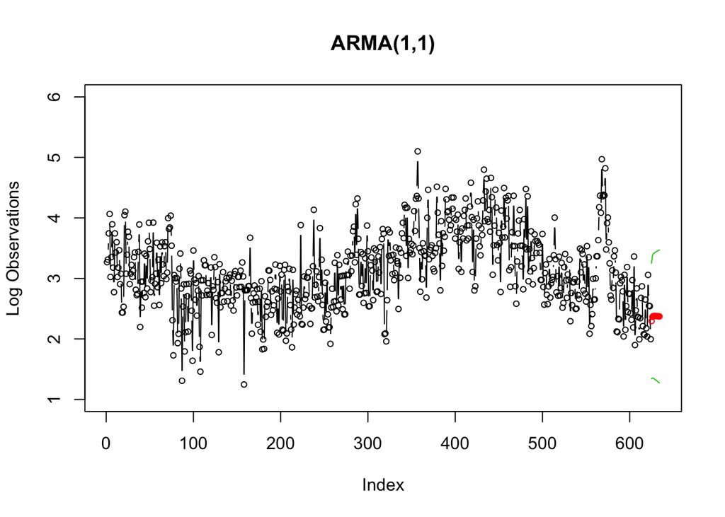

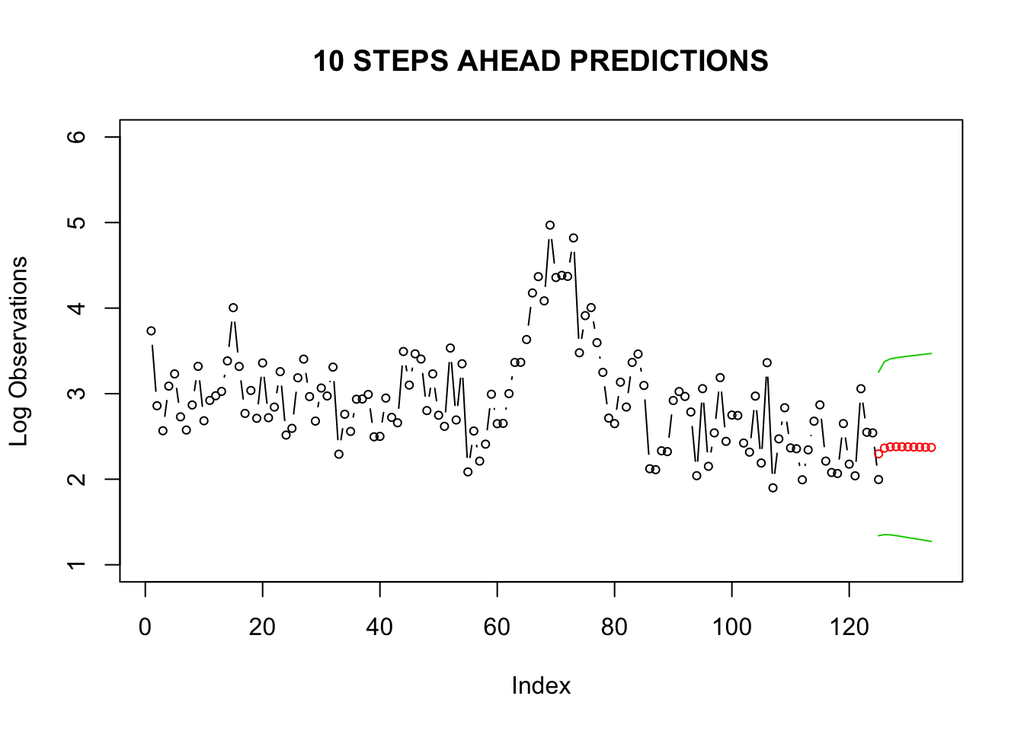

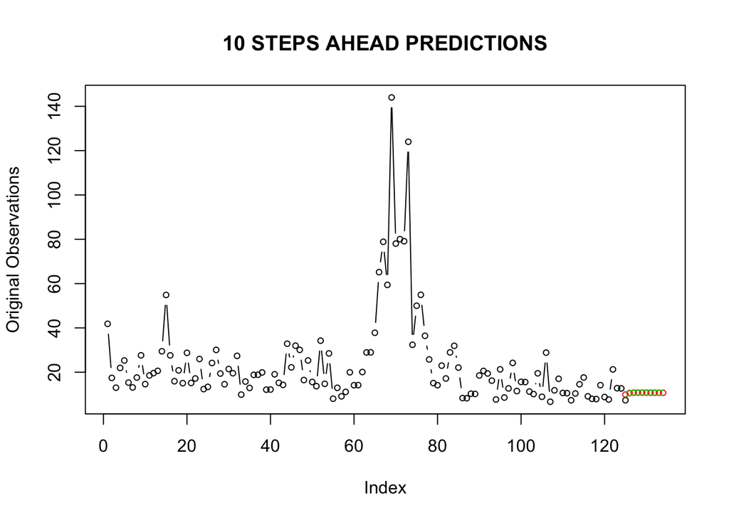

Figure 11. Predictions using ARMA(1,1)